# Wildlife Rehabilitation: analyses used in Davy et al.

James E Paterson

23 March, 2020

## Outline

This document contains the analyses for Davy et al. modelling the effects of wildlife rehabilitation on population trajectory and extinction risk.

We used five model species:

- Blanding’s Turtles
- Snapping Turtles
- Painted Turtles
- Common Raccoons
- Little Brown Myotis

This document is broken down by sections in the Methods & Results

1. Effects of additive mortality
2. Effects of rehabilitation

## 1. Effects of additive adult mortality

We used Population Viability Analyses (PVAs) in the program VORTEX to test how increases in mortality affect populations and extinction risk (this section) and whether that risk can be mitigated by rehabilitation (next section).

First, we loaded all the output data from the Vortex simulations.

```r
# Load data (csv file with cleaned output summaries for all scenarios)
wr.data <- read.csv(file = "Data/wrvortexdata_clean.csv")#,
                    #stringsAsFactors = FALSE)

# Ordering scenario name (important for colours and legends to properly line-up)
wr.data$scen.name2 <- factor(wr.data$scen.name2, levels = c("base", "+1% harvest",
                                            "+2% harvest", "+5% harvest",
                                             "+1% harvest +10% rehab","+1% harvest +25% rehab","+1% harvest +50% rehab",
                                            "+2% harvest +10% rehab","+2% harvest +25% rehab", "+2% harvest +50% rehab",
                                            "+5% harvest +10% rehab", "+5% harvest +25% rehab", "+5% harvest +50% rehab"))
```

We compared the population trajectory for all species under 4 scenarios:

1. Base (using long-term demographic estimates; see Table S1 in supplementary information for values and sources)
2. An increase in adult mortality of 1%
3. An increase in adult mortality of 2%, and
4. An increase in adult mortality of 5%

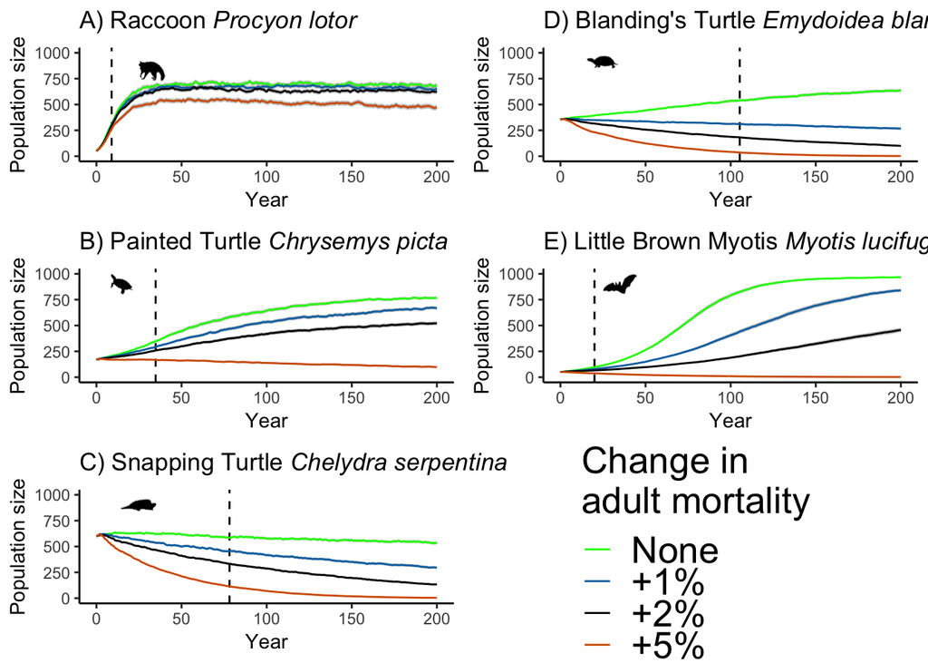

It is clear that populations of long-lived species (turtles and bats) are sensitive to small increases in adult mortality. For turtles, these mortality rates are expected based on traffic volume, road density, and wetland distribution in much of eastern North America. An increase of 5% is unsustainable for all three turtle species. For Blanding’s Turtles and Snapping Turtles (which mature later than Painted Turtles and have lower juvenile survival), even increases in adult mortality of 2% lead to population declines. Little Brown Bats declined when adult mortality was 5% per year.

| species | PExtant | group | PercentExtinct |
| --- | --- | --- | --- |
| BLTU | 0.999 | BLTU base | 0.1 |
| BLTU | 0.983 | BLTU +1% harvest | 1.7 |
| BLTU | 0.884 | BLTU +2% harvest | 11.6 |
| BLTU | 0.085 | BLTU +5% harvest | 91.5 |
| LBBA | 0.992 | LBBA base | 0.8 |
| LBBA | 0.974 | LBBA +1% harvest | 2.6 |
| LBBA | 0.875 | LBBA +2% harvest | 12.5 |
| LBBA | 0.072 | LBBA +5% harvest | 92.8 |
| PATU | 0.996 | PATU base | 0.4 |
| PATU | 0.989 | PATU +1% harvest | 1.1 |
| PATU | 0.959 | PATU +2% harvest | 4.1 |
| PATU | 0.643 | PATU +5% harvest | 35.7 |
| Racc | 0.949 | Racc base | 5.1 |
| Racc | 0.931 | Racc +1% harvest | 6.9 |
| Racc | 0.907 | Racc +2% harvest | 9.3 |
| Racc | 0.779 | Racc +5% harvest | 22.1 |
| SNTU | 1.000 | SNTU base | 0.0 |
| SNTU | 0.975 | SNTU +1% harvest | 2.5 |
| SNTU | 0.844 | SNTU +2% harvest | 15.6 |
| SNTU | 0.116 | SNTU +5% harvest | 88.4 |

## 2. Effects of wildlife rehabilitation

To test how wildlife rehabilitation affects wildlife populations, we modelled 3 different options for each mortality scenario:

1. 10% of injured adults are rehabilitated
2. 25% of injured adults are rehabilitated
3. 50% of injured adults are rehabilitated.

Below, we plot how wildlife rehabilitation affects each species.

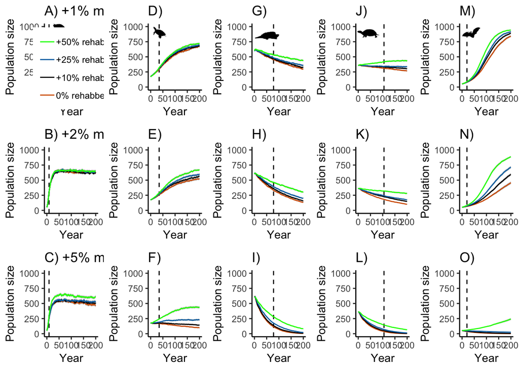

These plots clearly show that:

1. Populations are sensistive to increased mortality rates, and
2. Rehabilitating adults (and thus reducing mortality rates) can slow down or mitigate declines

How does wildlife rehabilitation affect the probability of extinction? In other words, how do different levels of wildlife rehabilitation affect the proportion of iterations that go extinct for each scenario?

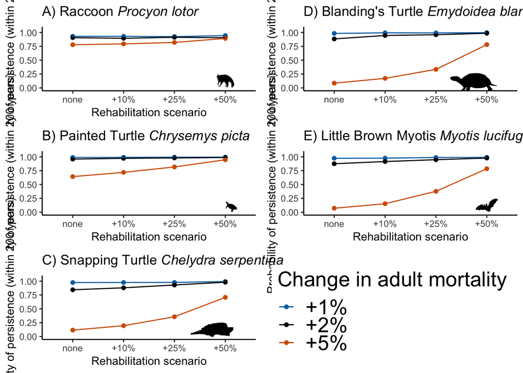

For both species, there was almost no risk of extinction when mortality was increased by 1% (regardless of rehabilitation levels).

| species | rehab | PExtant | PercentExtinct |
| --- | --- | --- | --- |
| BLTU | +10% | 0.994 | 0.6 |
| BLTU | +25% | 0.992 | 0.8 |
| BLTU | +50% | 0.997 | 0.3 |
| BLTU | none | 0.983 | 1.7 |
| SNTU | +10% | 0.976 | 2.4 |
| SNTU | +25% | 0.977 | 2.3 |
| SNTU | +50% | 0.993 | 0.7 |
| SNTU | none | 0.975 | 2.5 |

However, at 2% increases in mortality, rehabilitation reduced the chances of extinction within 200 years, especially for snapping turtles (from 16% with no rehab to <2% for rehabbing 50% of struck turtles).

| species | rehab | PExtant | PercentExtinct |
| --- | --- | --- | --- |
| BLTU | +10% | 0.946 | 5.4 |
| BLTU | +25% | 0.960 | 4.0 |
| BLTU | +50% | 0.986 | 1.4 |
| BLTU | none | 0.884 | 11.6 |
| SNTU | +10% | 0.880 | 12.0 |
| SNTU | +25% | 0.931 | 6.9 |
| SNTU | +50% | 0.981 | 1.9 |
| SNTU | none | 0.844 | 15.6 |

At increases of mortality of 5%, the probability of extinction within 200 years was high for both Blanding’s Turtles (92%) and Snapping Turtles (88%). Even small amounts of rehabilitation (10% of struck adults) led to decreases in the risk of extinction within 200 years (82% in Blanding’s Turtles, 80% in Snapping Turtles).

| species | rehab | PExtant | PercentExtinct |
| --- | --- | --- | --- |
| BLTU | +10% | 0.172 | 82.8 |
| BLTU | +25% | 0.334 | 66.6 |
| BLTU | +50% | 0.781 | 21.9 |
| BLTU | none | 0.085 | 91.5 |
| SNTU | +10% | 0.196 | 80.4 |
| SNTU | +25% | 0.357 | 64.3 |
| SNTU | +50% | 0.707 | 29.3 |
| SNTU | none | 0.116 | 88.4 |

Another useful way to examine the results of the probabilities of persistence is to use a heat map.

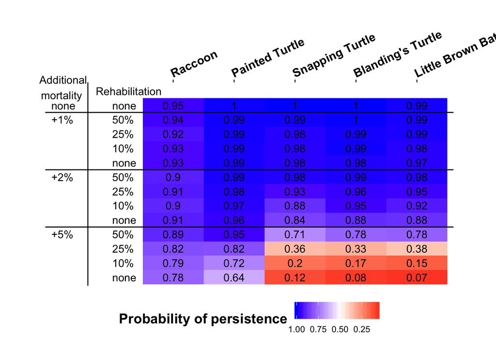